# Selenium proj

```python
!pip install selenium
!pip install webdriver_manager
```

##### Amazon Sneaker Sales Analysis – EDA Project

1. **Problem Definition**

Ravi is a working professional planning to buy a pair of sneakers for daily use. He visits Amazon and searches for sneakers, only to find thousands of options with similar-looking designs but huge price differences.

**Despite similar features like:**

Material quality

Brand type

Customer ratings

Usage type (casual, running, sports)

**He observes:**

Some sneakers cost ₹999 – ₹1,499 Others cost ₹3,000 – ₹8,000+ This creates confusion for Ravi and millions of online shoppers.

2. **Business Problem Statement**

Online sneaker buyers face difficulty in selecting the right product due to overwhelming choices and unclear pricing logic. The objective is to analyze Amazon sneaker data using Exploratory Data Analysis (EDA) to understand pricing patterns, feature impact, and value-for-money insights.

3. **Project Objectives**

Brand Representation

Gender Distribution

Selling Price Distribution

Discount Percentage Distribution

Rating Category Distribution

Selling Price vs Discount Amount

Price Category vs Rating

Gender vs Usage Type

Brand vs Average Rating

Average Selling Price by Price Category

Selling Price Distribution by Price Category

Provide data-driven insights for smarter buying decisions

4. **Data Analytics Life Cycle**

This project follows the standard Data Analytics Life Cycle:

1. Business Problem & Business Understanding

Understand customer confusion around sneaker pricing Identify buyer expectations (quality vs price) Define key analytical questions for EDA

2. Data Collection & Data Understanding

3. Data Preprocessing (Cleaning)

Remove currency symbols (₹, commas) from price columns Handle missing values in ratings and reviews Convert text-based numeric columns into integers/floats Remove duplicate product listings Standardize brand names

4. Exploratory Data Analysis (EDA)

#### Tools used:

Pandas

Matplotlib

Seaborn

5. **Conclusion**

- Helps buyers avoid overpriced products
- Enables smarter purchasing decisions
- Useful for retailers to optimize pricing strategies
- Strong real-world EDA portfolio project

### Importing All The Required Libraries

```python
from selenium import webdriver                      #to create a bridge between chrome and jupyter
from selenium.webdriver.chrome.service import Service  #if we want some servce from the chrome browser like installing of driver manager
from selenium.webdriver.chrome.options import Options   #options likem disable notifications and other functionality
from selenium.webdriver.common.by import By           #used to find the elements
from selenium.webdriver.common.keys import Keys        #keys is used to search something or to perform the clicks
from webdriver_manager.chrome import ChromeDriverManager    # install driver manager which will connect with your browser
import time                                     #to set a time delay because dyna,mic websites takes time to load the content
import pandas as pd
import re
```

```python
option = Options()
option.add_argument('--start-maximized') #== HEadless
service= Service(ChromeDriverManager().install())
```

```python
driver= webdriver.Chrome(service=service,options=option)
```

```python
url = 'https://www.amazon.in/s?k=sneakers&page=1'
url
```

```
'https://www.amazon.in/s?k=sneakers&page=1'
```

```python
driver.get(url)
```

```python
a = driver.find_elements(By.CSS_SELECTOR,".a-size-base-plus.a-color-base")[0].text
a
```

```
'Boldfit'
```

```python
button = driver.find_element(By.XPATH,'//*[@id="search"]/div[1]/div[1]/div/span[1]/div[1]/div[69]/div/div/span/ul/li[5]/span/a')
button.click()
```

```python
brands = []

brand_elements = driver.find_elements(
    By.CSS_SELECTOR,
    "h2.a-size-mini span.a-size-base-plus"
)

for brand in brand_elements:
    text = brand.text.strip()
    if text:
        brands.append(text)
```

```python
Brand_Names = []

for i in range(1,8):
    print(f"scraping Page{i}")
    url = f'https://www.amazon.in/s?k=sneakers&page={i}'
    driver.get(url)
    time.sleep(2)

    brand_elements = driver.find_elements(By.CSS_SELECTOR,"h2.a-size-mini span.a-size-base-plus")

    for brand in brand_elements:
        text = brand.text.strip()
        if text:
            Brand_Names.append(text)
```

```python
print("Total brands", len(Brand_Names))
print(Brand_Names[:5])
```

```
Total brands 944
['Boldfit', 'Boldfit', 'Campus', 'Boldfit', 'Campus']
```

```python
Gender = []

for page in range(1, 8):
    print(f"Scraping Page {page}")

    url = f"https://www.amazon.in/s?k=sneakers&page={page}"
    driver.get(url)
    time.sleep(2)

    title_elements = driver.find_elements(By.XPATH,'//h2[contains(@class,"a-size-base-plus")]//span')

    for title in title_elements:
        text = title.text.lower().strip()

        if not text:
            continue

        if re.search(r"\bmen\b|\bmens\b|\bman's\b", text):
            Gender.append("Men")
        elif re.search(r"\bwomen\b|\bwomens\b|\bwoman's\b", text):
            Gender.append("Women")
        elif "unisex" in text:
            Gender.append("Unisex")
        else:
            Gender.append("Unknown")
```

```python
MRP = []

for page in range(1, 8):
    url = f"https://www.amazon.in/s?k=sneakers&page={page}"
    driver.get(url)
    time.sleep(2)

    span_elements = driver.find_elements(By.TAG_NAME, 'span')
    for span in span_elements:
        text = span.text.strip()

        match = re.search(r"M\.R\.P:\s*₹([\d,]+)", text)

        if match:
            MRP.append(match.group(1))

    print(f"Page {page} scraped")

print("Total MRPs extracted:", len(MRP))
print(MRP[:10])
```

[output not shown]

```python
Discount_percent = []

for page in range(1, 8):
    url = f"https://www.amazon.in/s?k=sneakers&page={page}"
    driver.get(url)
    time.sleep(2)
    percent_elements = driver.find_elements(By.CLASS_NAME, 'a-row')

    for percent in percent_elements:
        text = percent.text.strip()

        match = re.search(r"\((\d+)%\s*off\)", text)

        if match:
            discount_percent = match.group(1)
            Discount_percent.append(discount_percent)

print("Total discount percentages extracted:", len(Discount_percent))
print(Discount_percent[:10])
```

```
Total discount percentages extracted: 834
['56', '56', '58', '58', '38', '38', '70', '70', '70', '70']
```

```python
Rating = []
for page in range(1, 8):
    url = f"https://www.amazon.in/s?k=sneakers&page={page}"
    driver.get(url)
    time.sleep(2)
    rating_elements = driver.find_elements(
        By.CLASS_NAME,
        "a-size-small.a-color-base"
)

    for rate in rating_elements:
        text = rate.text.strip()
        if text:
            Rating.append(text)
```

```python
Selling_Price = []
for page in range(1, 8):
    url = f"https://www.amazon.in/s?k=sneakers&page={page}"
    driver.get(url)
    time.sleep(2)
    selling_elements = driver.find_elements(
        By.CLASS_NAME,
        "a-price-whole"
)

    for rate in selling_elements:
        text = rate.text.strip()
        if text:
            Selling_Price.append(text)
```

```python
Usage_Type = []

for page in range(1, 8):
    print(f"Scraping Page {page}")

    url = f"https://www.amazon.in/s?k=sneakers&page={page}"
    driver.get(url)
    time.sleep(2)

    title_elements = driver.find_elements(
        By.XPATH, '//h2[contains(@class,"a-size-base-plus")]//span'
    )

    for title in title_elements:
        text = title.text.lower().strip()

        if not text:
            continue

        if re.search(r"\brunning\b|\bjogging\b|\brun\b", text):
            Usage_Type.append("Running")
        elif re.search(r"\bsports\b|\btraining\b|\bgym\b", text):
            Usage_Type.append("Sports")
        elif re.search(r"\bcasual\b|\bsneaker\b|\blifestyle\b|\bdaily\b", text):
            Usage_Type.append("Casual")
        else:
            Usage_Type.append("Unknown")
```

```python
Selling_Price = []
for page in range(1, 8):
    url = f"https://www.amazon.in/s?k=sneakers&page={page}"
    driver.get(url)
    time.sleep(2)
    selling_elements = driver.find_elements(
        By.CLASS_NAME,
        "a-price-whole"
)

    for rate in selling_elements:
        text = rate.text.strip()
        if text:
            Selling_Price.append(text)
```

#### Scraping The Data Is Completed

### Creating a DataFrame Using Pandas

```python
import pandas as pd
```

```python
min_len = min(
    len(Brand_Names),
    len(Gender),
    len(MRP),
    len(Selling_Price),
    len(Discount_percent),
    len(Rating)
)
```

```python
min_len
```

```
417
```

```python
df = pd.DataFrame({
    "Brand Name": Brand_Names[:min_len],
    "Gender": Gender[:min_len],
    "MRP": MRP[:min_len],
    "Selling Price": Selling_Price[:min_len],
    "Discount Percent": Discount_percent[:min_len],
    "Rating": Rating[:min_len]
})
```

```python
min_len = min(len(df), len(Usage_Type))

df = df.iloc[:min_len].copy()
df["Usage_Type"] = Usage_Type[:min_len]
```

#### DataFrame is Created

```python
df.head()
```

[output not shown]

```python
df.to_csv(r'C:\Users\sameer\Desktop\amazon_sneakers_new.csv')
```

```python
# This is the custom column to know how much discount is alloted in rupees basically it says How much money is saved
df["Discount Amount"] = df["MRP"] - df["Selling Price"]
```

```python
# cteated a price category column
df["Price_Category"] = pd.cut(
    df["Selling Price"],
    bins=[0, 1000, 2000, 3000, 5000, df["Selling Price"].max()],
    labels=["Budget", "Low-Mid", "Mid", "Upper-Mid", "Premium"]
)
```

```python
# created a rating based column
df["Rating_Category"] = pd.cut(
    df["Rating"],
    bins=[0, 3, 4, 4.5, 5],
    labels=["Poor", "Average", "Good", "Excellent"]
)
```

```python
df.head()
```

[output not shown]

```python
df.to_csv('amazon_sneakers.csv')
```

#### changing the datatypes

```python
df.info()
```

[output not shown]

#### converting MRP and Selling Price to integer

```python
df["MRP"] = (
    df["MRP"]
    .astype(str)
    .str.replace(",", "", regex=False)
    .astype(int)
)

df["Selling Price"] = (
    df["Selling Price"]
    .astype(str)
    .str.replace(",", "", regex=False)
    .astype(int)
)
```

```python
df.head()
```

|  | Brand Name | Gender | MRP | Selling Price | Discount Percent | Rating | Discount Amount | Price_Category | Rating_Category | Usage_Type |
| --- | --- | --- | --- | --- | --- | --- | --- | --- | --- | --- |
| 0 | Boldfit | Men | 1599 | 1499 | 56 | 3.8 | 100 | Low-Mid | Average | Casual |
| 1 | Boldfit | Men | 1599 | 1199 | 56 | 3.8 | 400 | Low-Mid | Average | Casual |
| 2 | Campus | Men | 1499 | 999 | 58 | 4.2 | 500 | Budget | Good | Unknown |
| 3 | Boldfit | Men | 999 | 1199 | 58 | 3.7 | -200 | Low-Mid | Average | Casual |
| 4 | Campus | Men | 3499 | 699 | 38 | 3.8 | 2800 | Budget | Average | Unknown |

#### Converting Rating To float Value

```python
df["Rating"] = pd.to_numeric(df["Rating"], errors="coerce")
```

```python
df.head()
```

|  | Brand Name | Gender | MRP | Selling Price | Discount Percent | Rating | Discount Amount | Price_Category | Rating_Category | Usage_Type |
| --- | --- | --- | --- | --- | --- | --- | --- | --- | --- | --- |
| 0 | Boldfit | Men | 1599 | 1499 | 56 | 3.8 | 100 | Low-Mid | Average | Casual |
| 1 | Boldfit | Men | 1599 | 1199 | 56 | 3.8 | 400 | Low-Mid | Average | Casual |
| 2 | Campus | Men | 1499 | 999 | 58 | 4.2 | 500 | Budget | Good | Unknown |
| 3 | Boldfit | Men | 999 | 1199 | 58 | 3.7 | -200 | Low-Mid | Average | Casual |
| 4 | Campus | Men | 3499 | 699 | 38 | 3.8 | 2800 | Budget | Average | Unknown |

```python
df.info()
```

```
<class 'pandas.core.frame.DataFrame'>
RangeIndex: 417 entries, 0 to 416
Data columns (total 10 columns):
 #   Column            Non-Null Count  Dtype
---  ------            --------------  -----
 0   Brand Name        417 non-null    object
 1   Gender            417 non-null    object
 2   MRP               417 non-null    int64
 3   Selling Price     417 non-null    int64
 4   Discount Percent  417 non-null    object
 5   Rating            411 non-null    float64
 6   Discount Amount   417 non-null    int64
 7   Price_Category    417 non-null    category
 8   Rating_Category   411 non-null    category
 9   Usage_Type        417 non-null    object
dtypes: category(2), float64(1), int64(3), object(4)
memory usage: 27.4+ KB
```

```python
pd.read_csv(r"C:\Users\sameer\Desktop\amazon_sneakers_new.csv")
```

|  | Unnamed: 0 | Brand Name | Gender | MRP | Selling Price | Discount Percent | Rating | Discount Amount | Price_Category | Rating_Category | Usage_Type |
| --- | --- | --- | --- | --- | --- | --- | --- | --- | --- | --- | --- |
| 0 | 0 | Boldfit | Men | 1599 | 1499 | 56 | 3.8 | 100 | Low-Mid | Average | Casual |
| 1 | 1 | Boldfit | Men | 1599 | 1199 | 56 | 3.8 | 400 | Low-Mid | Average | Casual |
| 2 | 2 | Campus | Men | 1499 | 999 | 58 | 4.2 | 500 | Budget | Good | Unknown |
| 3 | 3 | Boldfit | Men | 999 | 1199 | 58 | 3.7 | -200 | Low-Mid | Average | Casual |
| 4 | 4 | Campus | Men | 3499 | 699 | 38 | 3.8 | 2800 | Budget | Average | Unknown |
| ... | ... | ... | ... | ... | ... | ... | ... | ... | ... | ... | ... |
| 412 | 412 | Cruiser | Women | 2499 | 1304 | 67 | 3.3 | 1195 | Low-Mid | Average | Casual |
| 413 | 413 | Campus | Men | 2499 | 849 | 67 | 4.3 | 1650 | Budget | Good | Casual |
| 414 | 414 | Bacca Bucci | Women | 2499 | 799 | 57 | 4.6 | 1700 | Budget | Excellent | Casual |
| 415 | 415 | Boldfit | Women | 5299 | 1499 | 57 | 3.8 | 3800 | Low-Mid | Average | Casual |
| 416 | 416 | Campus | Men | 2499 | 899 | 52 | 4.0 | 1600 | Budget | Average | Unknown |

417 rows × 11 columns

```python
df.dtypes
```

[output not shown]

```python
df['Usage_Type'] = df['Usage_Type'].astype('category')
```

```python
df.dtypes
```

```
Brand Name            object
Gender                object
MRP                    int64
Selling Price          int64
Discount Percent      object
Rating               float64
Discount Amount        int64
Price_Category      category
Rating_Category     category
Usage_Type          category
dtype: object
```

```python
df
```

|  | Brand Name | Gender | MRP | Selling Price | Discount Percent | Rating | Discount Amount | Price_Category | Rating_Category | Usage_Type |
| --- | --- | --- | --- | --- | --- | --- | --- | --- | --- | --- |
| 0 | Boldfit | Men | 1599 | 1499 | 56 | 3.8 | 100 | Low-Mid | Average | Casual |
| 1 | Boldfit | Men | 1599 | 1199 | 56 | 3.8 | 400 | Low-Mid | Average | Casual |
| 2 | Campus | Men | 1499 | 999 | 58 | 4.2 | 500 | Budget | Good | Unknown |
| 3 | Boldfit | Men | 999 | 1199 | 58 | 3.7 | -200 | Low-Mid | Average | Casual |
| 4 | Campus | Men | 3499 | 699 | 38 | 3.8 | 2800 | Budget | Average | Unknown |
| ... | ... | ... | ... | ... | ... | ... | ... | ... | ... | ... |
| 412 | Cruiser | Women | 2499 | 1304 | 67 | 3.3 | 1195 | Low-Mid | Average | Casual |
| 413 | Campus | Men | 2499 | 849 | 67 | 4.3 | 1650 | Budget | Good | Casual |
| 414 | Bacca Bucci | Women | 2499 | 799 | 57 | 4.6 | 1700 | Budget | Excellent | Casual |
| 415 | Boldfit | Women | 5299 | 1499 | 57 | 3.8 | 3800 | Low-Mid | Average | Casual |
| 416 | Campus | Men | 2499 | 899 | 52 | 4.0 | 1600 | Budget | Average | Unknown |

417 rows × 10 columns

### Filling Null Values

```python
df.isna().sum()
```

[output not shown]

```python
mode_value = df['Rating'].mode()[0]
mode_value
```

```
np.float64(4.1)
```

```python
df['Rating'] = df['Rating'].fillna(mode_value)
```

```python
mode_category = df['Rating_Category'].mode()[0]
df['Rating_Category'] = df['Rating_Category'].fillna(mode_category)
```

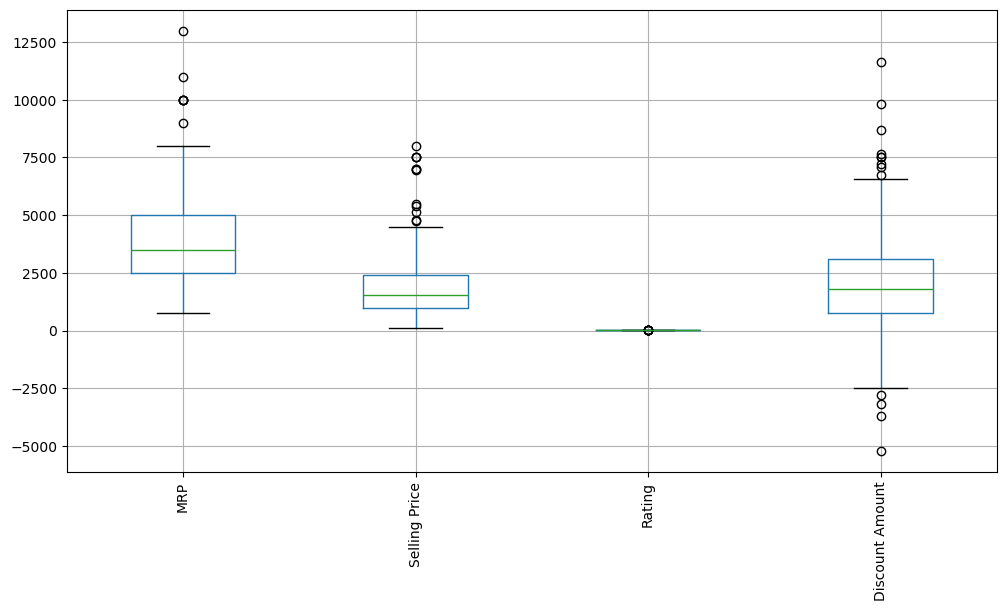

```python
import matplotlib.pyplot as plt

df.select_dtypes(include='number').boxplot(figsize=(12,6))
plt.xticks(rotation=90)
plt.show()
```

#### With this Box plot i got to know that there are negative values in Discount Amount Columns

#### Converting negative values to positive

```python
df['Discount Amount'] = df['Discount Amount'].abs()
```

```python
df.head(3)
```

|  | Brand Name | Gender | MRP | Selling Price | Discount Percent | Rating | Discount Amount | Price_Category | Rating_Category | Usage_Type |
| --- | --- | --- | --- | --- | --- | --- | --- | --- | --- | --- |
| 0 | Boldfit | Men | 1599 | 1499 | 56 | 3.8 | 100 | Low-Mid | Average | Casual |
| 1 | Boldfit | Men | 1599 | 1199 | 56 | 3.8 | 400 | Low-Mid | Average | Casual |
| 2 | Campus | Men | 1499 | 999 | 58 | 4.2 | 500 | Budget | Good | Unknown |

#### Fixing Unknown Category using mapping / apply

```python
def mapping(un):
    if un == 'Unknown':
        return 'Unisex'
    else:
        return un

df['Gender'] = df['Gender'].apply(mapping)
```

```python
df
```

|  | Brand Name | Gender | MRP | Selling Price | Discount Percent | Rating | Discount Amount | Price_Category | Rating_Category | Usage_Type |
| --- | --- | --- | --- | --- | --- | --- | --- | --- | --- | --- |
| 0 | Boldfit | Men | 1599 | 1499 | 56 | 3.8 | 100 | Low-Mid | Average | Casual |
| 1 | Boldfit | Men | 1599 | 1199 | 56 | 3.8 | 400 | Low-Mid | Average | Casual |
| 2 | Campus | Men | 1499 | 999 | 58 | 4.2 | 500 | Budget | Good | Unknown |
| 3 | Boldfit | Men | 999 | 1199 | 58 | 3.7 | 200 | Low-Mid | Average | Casual |
| 4 | Campus | Men | 3499 | 699 | 38 | 3.8 | 2800 | Budget | Average | Unknown |
| ... | ... | ... | ... | ... | ... | ... | ... | ... | ... | ... |
| 412 | Cruiser | Women | 2499 | 1304 | 67 | 3.3 | 1195 | Low-Mid | Average | Casual |
| 413 | Campus | Men | 2499 | 849 | 67 | 4.3 | 1650 | Budget | Good | Casual |
| 414 | Bacca Bucci | Women | 2499 | 799 | 57 | 4.6 | 1700 | Budget | Excellent | Casual |
| 415 | Boldfit | Women | 5299 | 1499 | 57 | 3.8 | 3800 | Low-Mid | Average | Casual |
| 416 | Campus | Men | 2499 | 899 | 52 | 4.0 | 1600 | Budget | Average | Unknown |

417 rows × 10 columns

```python
def mapping2(snek):
    if snek == 'Unknown':
        return 'Sneaker'
    else:
        return snek

df['Usage_Type'] = df['Usage_Type'].apply(mapping2)
```

```python
df.to_csv('Amazon cleaned version1.csv')
```

```python
df = pd.read_csv(r"C:\Users\sameer\INNOMATICS\Web Scraping\Amazon cleaned version1.csv")
```

```python
df
```

|  | Unnamed: 0 | Brand Name | Gender | MRP | Selling Price | Discount Percent | Rating | Discount Amount | Price_Category | Rating_Category | Usage_Type |
| --- | --- | --- | --- | --- | --- | --- | --- | --- | --- | --- | --- |
| 0 | 0 | Boldfit | Men | 1599 | 1499 | 56 | 3.8 | 100 | Low-Mid | Average | Casual |
| 1 | 1 | Boldfit | Men | 1599 | 1199 | 56 | 3.8 | 400 | Low-Mid | Average | Casual |
| 2 | 2 | Campus | Men | 1499 | 999 | 58 | 4.2 | 500 | Budget | Good | Sneaker |
| 3 | 3 | Boldfit | Men | 999 | 1199 | 58 | 3.7 | 200 | Low-Mid | Average | Casual |
| 4 | 4 | Campus | Men | 3499 | 699 | 38 | 3.8 | 2800 | Budget | Average | Sneaker |
| ... | ... | ... | ... | ... | ... | ... | ... | ... | ... | ... | ... |
| 412 | 412 | Cruiser | Women | 2499 | 1304 | 67 | 3.3 | 1195 | Low-Mid | Average | Casual |
| 413 | 413 | Campus | Men | 2499 | 849 | 67 | 4.3 | 1650 | Budget | Good | Casual |
| 414 | 414 | Bacca Bucci | Women | 2499 | 799 | 57 | 4.6 | 1700 | Budget | Excellent | Casual |
| 415 | 415 | Boldfit | Women | 5299 | 1499 | 57 | 3.8 | 3800 | Low-Mid | Average | Casual |
| 416 | 416 | Campus | Men | 2499 | 899 | 52 | 4.0 | 1600 | Budget | Average | Sneaker |

417 rows × 11 columns

#### The cleaning Part is finally completed

## EDA ( Exploratory Data Analysis )

```python
import seaborn as sns
import matplotlib.pyplot as plt
import warnings
warnings.filterwarnings('ignore')
```

```python
df.shape
```

```
(417, 11)
```

```python
df.info()
```

```
<class 'pandas.core.frame.DataFrame'>
RangeIndex: 417 entries, 0 to 416
Data columns (total 11 columns):
 #   Column            Non-Null Count  Dtype
---  ------            --------------  -----
 0   Unnamed: 0        417 non-null    int64
 1   Brand Name        417 non-null    object
 2   Gender            417 non-null    object
 3   MRP               417 non-null    int64
 4   Selling Price     417 non-null    int64
 5   Discount Percent  417 non-null    int64
 6   Rating            417 non-null    float64
 7   Discount Amount   417 non-null    int64
 8   Price_Category    417 non-null    object
 9   Rating_Category   417 non-null    object
 10  Usage_Type        417 non-null    object
dtypes: float64(1), int64(5), object(5)
memory usage: 36.0+ KB
```

```python
df.describe()
```

|  | Unnamed: 0 | MRP | Selling Price | Discount Percent | Rating | Discount Amount |
| --- | --- | --- | --- | --- | --- | --- |
| count | 417.000000 | 417.000000 | 417.000000 | 417.000000 | 417.00000 | 417.000000 |
| mean | 208.000000 | 3901.438849 | 1831.853717 | 54.570743 | 4.10000 | 2287.134293 |
| std | 120.521782 | 1853.050887 | 1188.149804 | 12.979289 | 0.45144 | 1790.471225 |
| min | 0.000000 | 749.000000 | 99.000000 | 10.000000 | 2.40000 | 1.000000 |
| 25% | 104.000000 | 2499.000000 | 959.000000 | 49.000000 | 3.80000 | 890.000000 |
| 50% | 208.000000 | 3499.000000 | 1534.000000 | 55.000000 | 4.10000 | 1891.000000 |
| 75% | 312.000000 | 4999.000000 | 2386.000000 | 64.000000 | 4.30000 | 3112.000000 |
| max | 416.000000 | 12999.000000 | 7999.000000 | 80.000000 | 5.00000 | 11635.000000 |

## Brand Representation

Plot Type: Horizontal Bar Chart (Top 10)

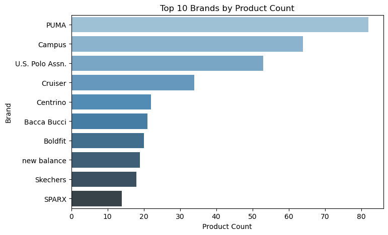

```python
top_brands = df['Brand Name'].value_counts().head(10)

plt.figure(figsize=(8,5))
sns.barplot(
    x=top_brands.values,
    y=top_brands.index,
    palette='Blues_d'
)
plt.title('Top 10 Brands by Product Count')
plt.xlabel('Product Count')
plt.ylabel('Brand')
plt.show()
```

#### Key Insights:

A few brands dominate the platform in terms of product availability.

The remaining brands form a long tail with limited listings.

## Gender Distribution

Plot Type: Donut Chart

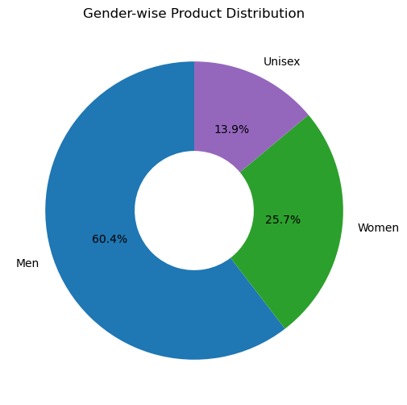

```python
gender_counts = df['Gender'].value_counts()

plt.figure(figsize=(6,6))
plt.pie(
    gender_counts,
    labels=gender_counts.index,
    autopct='%1.1f%%',
    startangle=90,
    colors=['#1F77B4', '#2CA02C', '#9467BD'],
    wedgeprops=dict(width=0.6)
)
plt.title('Gender-wise Product Distribution')
plt.show()
```

#### Key Insights:

Men’s footwear clearly dominates the dataset.

Women and unisex categories have relatively lower representation.

## Selling Price Distribution

Plot Type: Histogram with KDE

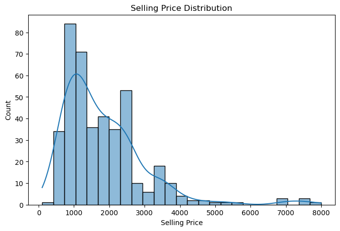

```python
plt.figure(figsize=(8,5))
sns.histplot(
    df['Selling Price'],
    bins=25,
    kde=True,
    color='#1F77B4'
)
plt.title('Selling Price Distribution')
plt.xlabel('Selling Price')
plt.show()
```

#### Key Insights:

Majority of products are concentrated in the lower price range.

Few high-priced products create a right-skewed distribution.

## Discount Percentage Distribution

Plot Type: Box Plot

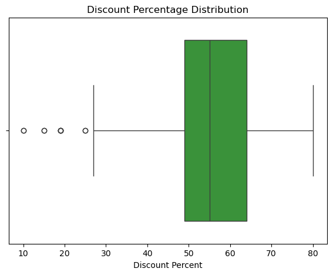

```python
plt.figure(figsize=(7,5))
sns.boxplot(
    x=df['Discount Percent'],
    color='#2CA02C'
)
plt.title('Discount Percentage Distribution')
plt.xlabel('Discount Percent')
plt.show()
```

#### Key Insights:

High discount percentages are common across most products.

## Rating Category Distribution

Plot Type: Ordered Count Plot

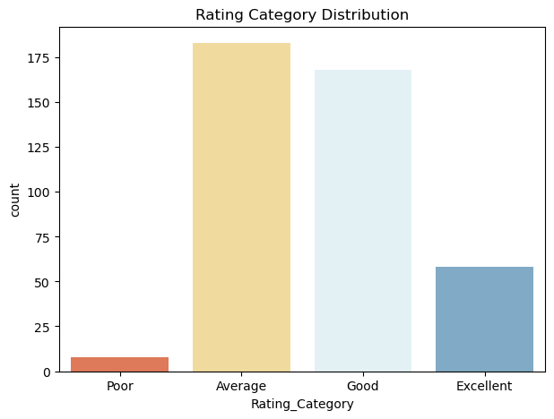

```python
rating_order = ['Poor','Average','Good','Excellent']

plt.figure(figsize=(7,5))
sns.countplot(
    x='Rating_Category',
    data=df,
    order=rating_order,
    palette='RdYlBu'
)
plt.title('Rating Category Distribution')
plt.show()
```

#### Key Insights:

Most products fall under Average and Good rating categories.

Excellent-rated products are comparatively fewer.

# BIVARIATE ANALYSIS

## Selling Price vs Discount Amount

Plot Type: Scatter Plot

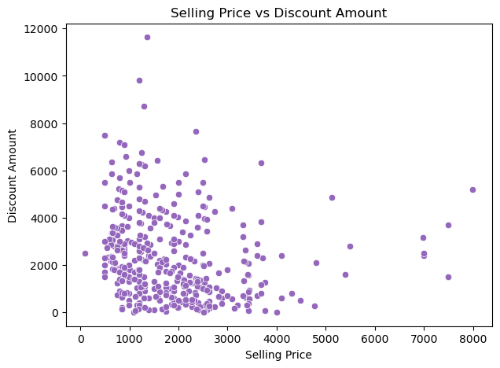

```python
plt.figure(figsize=(7,5))
sns.scatterplot(
    x='Selling Price',
    y='Discount Amount',
    data=df,
    color='#9467BD'
)
plt.title('Selling Price vs Discount Amount')
plt.show()
```

## Price Category vs Rating

Plot Type: Box Plot

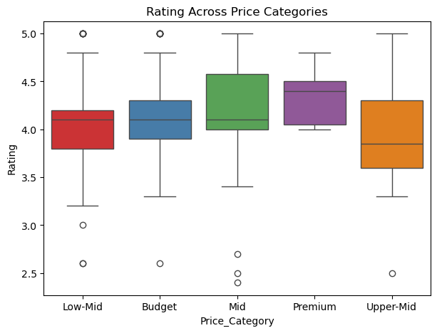

```python
plt.figure(figsize=(7,5))
sns.boxplot(
    x='Price_Category',
    y='Rating',
    data=df,
    palette='Set1'
)
plt.title('Rating Across Price Categories')
plt.show()
```

#### Key Insights:

Higher price does not consistently translate into higher ratings.

Value perception plays a stronger role than price alone.

## Gender vs Usage Type

Plot Type: Grouped Count Plot

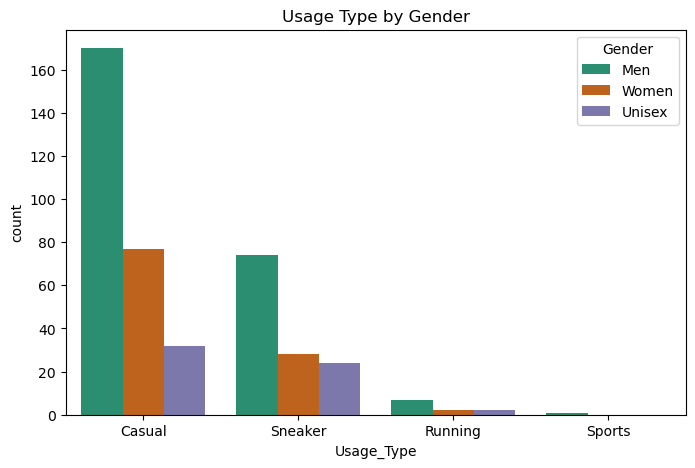

```python
plt.figure(figsize=(8,5))
sns.countplot(
    x='Usage_Type',
    hue='Gender',
    data=df,
    palette='Dark2'
)
plt.title('Usage Type by Gender')
plt.show()
```

#### Key Insights:

Casual footwear dominates across all genders.

Men show higher product availability across usage types.

## Brand vs Average Rating

Plot Type: Aggregated Bar Chart

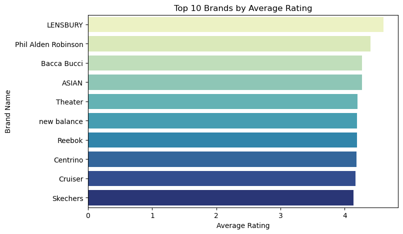

```python
brand_rating = (
    df.groupby('Brand Name')['Rating']
      .mean()
      .sort_values(ascending=False)
      .head(10)
)

plt.figure(figsize=(8,5))
sns.barplot(
    x=brand_rating.values,
    y=brand_rating.index,
    palette='YlGnBu'
)
plt.title('Top 10 Brands by Average Rating')
plt.xlabel('Average Rating')
plt.show()
```

#### Key Insights:

Some less frequent brands outperform popular brands in ratings.

Product volume does not guarantee better customer satisfaction.

## Average Selling Price by Price Category

Plot Type: Line Chart (Bivariate Analysis)

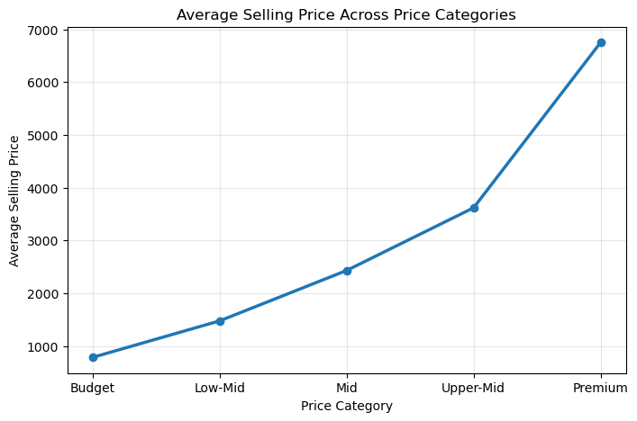

```python
price_trend = (
    df.groupby('Price_Category')['Selling Price']
      .mean()
      .reindex(['Budget', 'Low-Mid', 'Mid', 'Upper-Mid', 'Premium'])
)

plt.figure(figsize=(8,5))
plt.plot(
    price_trend.index,
    price_trend.values,
    marker='o',
    linewidth=2.5,
    color='#1F77B4'
)

plt.title('Average Selling Price Across Price Categories')
plt.xlabel('Price Category')
plt.ylabel('Average Selling Price')
plt.grid(alpha=0.3)
plt.show()
```

#### Key Insights

Average selling price increases consistently across higher price categories.

This confirms that the price categories are logically defined and well segmented.

## Selling Price Distribution by Price Category

Plot Type: KDE Line Chart Analysis Type: Bivariate Analysis (Price vs Category)

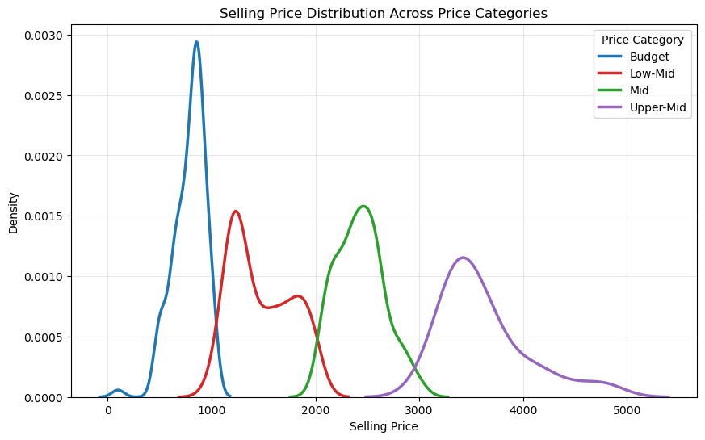

```python
import seaborn as sns
import matplotlib.pyplot as plt

plt.figure(figsize=(10,6))

colors = {
    'Budget': '#1f77b4',
    'Low-Mid': '#d62728',
    'Mid': '#2ca02c',
    'Upper-Mid': '#9467bd',
}

for category, color in colors.items():
    sns.kdeplot(
        data=df[df['Price_Category'] == category],
        x='Selling Price',
        linewidth=2.5,
        label=category,
        color=color
    )

plt.title('Selling Price Distribution Across Price Categories')
plt.xlabel('Selling Price')
plt.ylabel('Density')
plt.legend(title='Price Category')
plt.grid(alpha=0.3)
plt.show()
```

## Hypothesis Testing

### Hypothesis Test 1

Is there a significant difference in Selling Price across Price Categories? (ANOVA)

**Hypotheses**

- H₀: Mean Selling Price is same across all Price Categories
- H₁: Mean Selling Price differs across Price Categories

```python
from scipy.stats import f_oneway

groups = []
for cat in df['Price_Category'].unique():
    groups.append(df[df['Price_Category'] == cat]['Selling Price'].values)

stat, p_value = f_oneway(*groups)

cl = 0.95
alpha = 1 - cl

if p_value <= alpha:
    print("Reject Null Hypothesis i.e There is relationship between Price Category and Selling Price")
else:
    print("Failed to reject Null Hypothesis i.e There is no relationship between Price Category and Selling Price")
```

```
Reject Null Hypothesis i.e There is relationship between Price Category and Selling Price
```

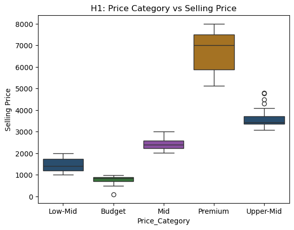

```python
sns.boxplot(
    x=df['Price_Category'],
    y=df['Selling Price'],
    palette=['#1f4e79', '#2e7d32', '#8e44ad', '#b9770e']
)
plt.title('H1: Price Category vs Selling Price')
plt.show()
```

**Conclusion**

Reject Null Hypothesis

Selling prices vary significantly across different price categories.

### Hypothesis Test 2

Does Rating Category depend on Gender? (Chi-Square Test)

**Hypotheses**

H₀ (Null Hypothesis): Gender and Rating_Category are independent (no relationship).

H₁ (Alternative Hypothesis): Gender and Rating_Category are dependent (there is a relationship).

```python
from scipy.stats import chi2_contingency

contingency_table = pd.crosstab(df['Gender'], df['Rating_Category'])

chi2, p_value, dof, expected = chi2_contingency(contingency_table)

cl = 0.95
alpha = 1 - cl

if p_value <= alpha:
    print("Reject Null Hypothesis i.e There is relationship between Gender and Rating Category")
else:
    print("Failed to reject Null Hypothesis i.e There is no relationship between Gender and Rating Category")

chi2, p_value
```

```
Reject Null Hypothesis i.e There is relationship between Gender and Rating Category
```

```
(np.float64(19.282105800436284), np.float64(0.0037128015487434343))
```

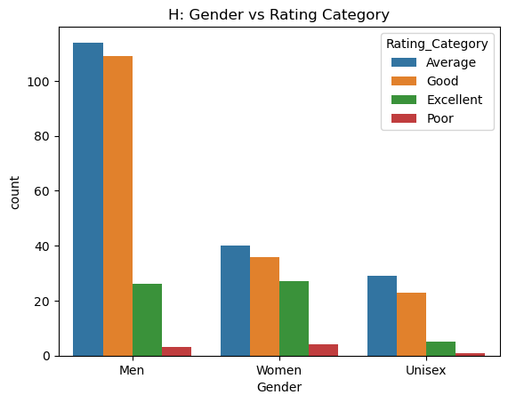

```python
sns.countplot(x='Gender', hue='Rating_Category', data=df)
plt.title('H: Gender vs Rating Category')
plt.show()
```

**Conclusion**

Reject Null Hypothesis

Customer rating category is significantly associated with gender.

### Hypothesis Test 3

Does Customer Rating differ between Men and Women? (Independent T-Test)

**Hypotheses**

H₀ (Null Hypothesis): Mean ratings of Men and Women are the same

H₁ (Alternative Hypothesis): Mean ratings of Men and Women are different

```python
from scipy.stats import ttest_ind


men_ratings = df[df['Gender'] == 'Men']['Rating']
women_ratings = df[df['Gender'] == 'Women']['Rating']


t_stat, p_value = ttest_ind(men_ratings, women_ratings, equal_var=False)

cl = 0.95
alpha = 1 - cl

if p_value <= alpha:
    print("Reject Null Hypothesis i.e There is relationship between Gender and Rating")
else:
    print("Failed to reject Null Hypothesis i.e There is no relationship between Gender and Rating")

t_stat, p_value
```

```
Reject Null Hypothesis i.e There is relationship between Gender and Rating
```

```
(np.float64(-2.117603592155263), np.float64(0.03583337500977744))
```

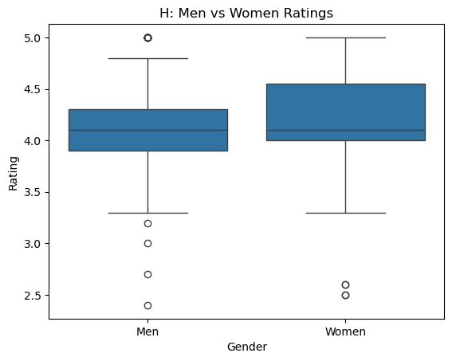

```python
sns.boxplot(x='Gender', y='Rating', data=df[df['Gender'].isin(['Men','Women'])])
plt.title('H: Men vs Women Ratings')
plt.show()
```

**Conclusion**

Reject Null Hypothesis

Customer ratings differ significantly between Men and Women categories.

## PROJECT CONCLUSION

This project focused on analyzing Amazon sneaker product data to understand pricing behavior, customer perception, and discount strategies using Exploratory Data Analysis (EDA) and statistical hypothesis testing.

**Exploratory Data Analysis Summary**

The dataset contained sneakers across multiple brands, genders, price categories, usage types, and rating categories.

Most products belonged to the Budget and Low-Mid price segments, indicating a strong price-sensitive customer base.

Ratings were largely concentrated between 3.5 to 4.5, showing generally positive customer satisfaction.

Casual usage sneakers dominated the dataset, highlighting higher demand for everyday wear compared to specialized usage.

**Univariate Analysis**

Univariate analysis was used to understand the individual distribution of sneaker attributes.

The dataset is dominated by men’s sneakers, indicating higher availability and demand in this segment.

Most sneakers fall under the Budget and Low-Mid price categories, showing that affordability is a key factor in the sneaker market.

Customer ratings are mostly concentrated between 3.5 and 4.5, reflecting generally good product satisfaction.

Casual and sneaker usage types appear most frequently, highlighting everyday wear as the primary use case.

**Insight:** The sneaker market strongly targets affordable, well-rated products focused on daily and casual use.

**Bivariate Analysis**

Bivariate analysis helped identify relationships between sneaker attributes.

Selling prices vary significantly across price categories, confirming that categorization effectively separates sneakers by market segment.

Customer ratings differ across gender, suggesting variations in preferences or perceived comfort and design.

### Overall Business Takeaways

Pricing and discounting strategies play a key role in customer purchasing behavior.

Gender impacts customer feedback and should be considered for targeted marketing.

Budget-friendly products with good ratings present the strongest value proposition.